# Analysis_ReadingLinearity

### Model Assumptions

All generalised linear mixed models were tested for (1) multicollinearity, (2) influential observations, (3) heteroscedasticity, and (4) normality of random effects.

Under- and overdispersion was not tested considering that the observations cannot be effectively grouped by predictors (see https://stats.stackexchange.com/a/200848).

#### 1. Multicollinearity

Multicollinearity is checked by first inspecting a correlation matrix, and then computing Variance Inflation Factors (VIF) for all predictors. Any VIF > 5 is considered to be a strong indication of multicollinearity, and thus those predictors should be removed. Any VIFs that are in the moderate range 1 < VIF < 5 are inspected before removing them. If removing the variable with a moderate VIF influences the model interpretation of predictors (not including the one that is removed), then the predictor should be removed from the model.

We check for multicollinearity first with a correlation matrix:

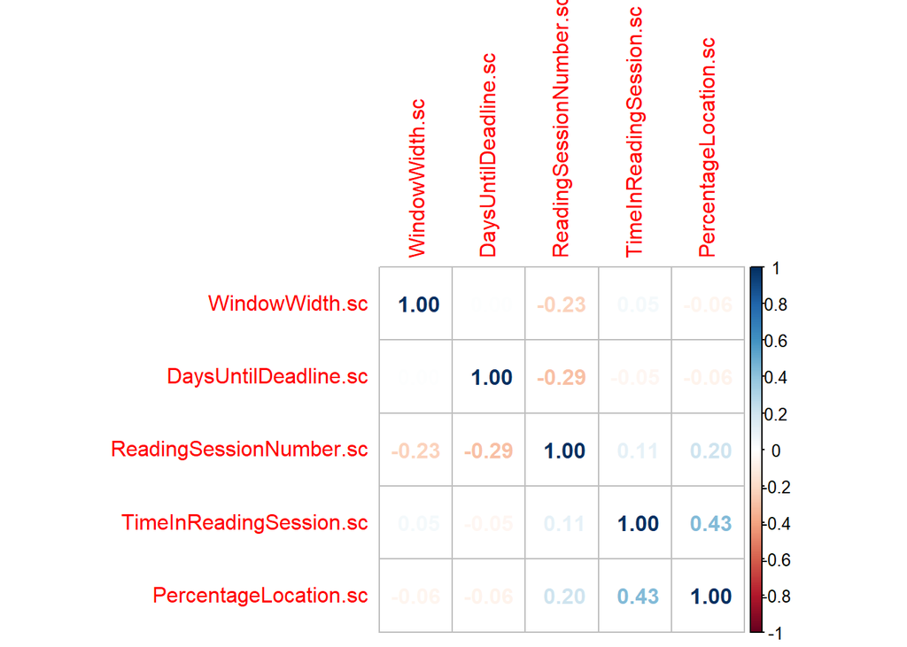

```r
corrplot(cor(linearity_measure_data[, c("WindowWidth.sc", "DaysUntilDeadline.sc", "ReadingSessionNumber.sc", "TimeInReadingSession.sc", "PercentageLocation.sc")]), method = "number")
```

Location in text and time in a reading session are positively correlated, *r* = 0.43.

To check if these correlations are problematic, we calculate VIF:

```r
check_collinearity(Linearity_EP_InteractiveModel)
```

```
## # Check for Multicollinearity
##
## Low Correlation
##
##                                             Term  VIF   VIF 95% CI Increased SE
##                                          StoryId 1.73 [1.66, 1.81]         1.32
##                                   WindowWidth.sc 1.23 [1.19, 1.28]         1.11
##                             DaysUntilDeadline.sc 1.33 [1.28, 1.38]         1.15
##                                 Observation_lag1 1.85 [1.77, 1.94]         1.36
##                                 Observation_lag2 4.91 [4.64, 5.20]         2.22
##                          ReadingSessionNumber.sc 1.57 [1.51, 1.64]         1.25
##                          TimeInReadingSession.sc 1.54 [1.47, 1.60]         1.24
##                            PercentageLocation.sc 1.55 [1.49, 1.62]         1.25
##  ReadingSessionNumber.sc:TimeInReadingSession.sc 1.28 [1.24, 1.34]         1.13
##    ReadingSessionNumber.sc:PercentageLocation.sc 1.28 [1.23, 1.33]         1.13
##    TimeInReadingSession.sc:PercentageLocation.sc 1.11 [1.08, 1.16]         1.05
##  Tolerance Tolerance 95% CI
##       0.58     [0.55, 0.60]
##       0.82     [0.78, 0.84]
##       0.75     [0.72, 0.78]
##       0.54     [0.51, 0.56]
##       0.20     [0.19, 0.22]
##       0.64     [0.61, 0.66]
##       0.65     [0.62, 0.68]
##       0.64     [0.62, 0.67]
##       0.78     [0.75, 0.81]
##       0.78     [0.75, 0.81]
##       0.90     [0.86, 0.93]
##
## Moderate Correlation
##
##                               Term  VIF   VIF 95% CI Increased SE Tolerance
##  Observation_lag1:Observation_lag2 5.28 [4.99, 5.60]         2.30      0.19
##  Tolerance 95% CI
##      [0.18, 0.20]
```

```
## Variable `Component` is not in your data frame :/
```

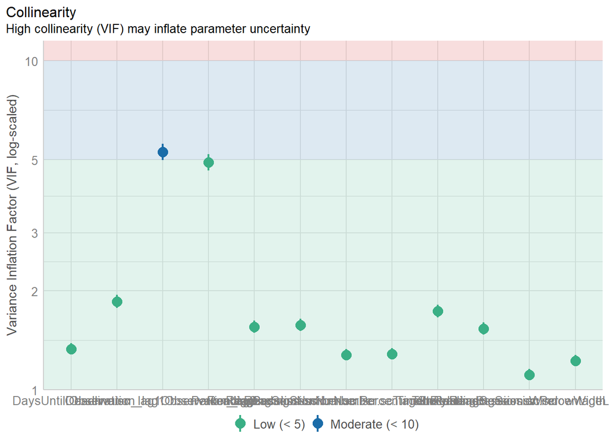

```r
plot(check_collinearity(Linearity_EP_InteractiveModel))
```

An interaction effect between the previous events (Event k-1 and k-2) have a moderately high VIF score. We further assess whether the multicollinearity influences results by re-fitting the model without it.

```r
# Specify model without an interaction between previous events
InteractiveStructure_EP_adjusted <- (
    "StartsNonlinearity ~ StoryId + WindowWidth.sc + DaysUntilDeadline.sc + Observation_lag1 + Observation_lag2 + ReadingSessionNumber.sc + TimeInReadingSession.sc + PercentageLocation.sc + ReadingSessionNumber.sc : TimeInReadingSession.sc + ReadingSessionNumber.sc : PercentageLocation.sc + TimeInReadingSession.sc : PercentageLocation.sc + (1 + TimeInReadingSession.sc + Observation_lag1 | UserId)"
)
# Re-fit the model
Linearity_EP_InteractiveModel_adjusted <- glmer(
    InteractiveStructure_EP_adjusted,
    data = linearity_measure_data,
    family = binomial(),
    control = glmerControl(optimizer = "bobyqa")
)
anova(Linearity_EP_InteractiveModel_adjusted, Linearity_EP_InteractiveModel)
```

```
## Data: linearity_measure_data
## Models:
## Linearity_EP_InteractiveModel_adjusted: StartsNonlinearity ~ StoryId + WindowWidth.sc + DaysUntilDeadline.sc + Observation_lag1 + Observation_lag2 + ReadingSessionNumber.sc + TimeInReadingSession.sc + PercentageLocation.sc + ReadingSessionNumber.sc:TimeInReadingSession.sc + ReadingSessionNumber.s…
## Linearity_EP_InteractiveModel: StartsNonlinearity ~ StoryId + WindowWidth.sc + DaysUntilDeadline.sc + Observation_lag1 + Observation_lag2 + ReadingSessionNumber.sc + TimeInReadingSession.sc + PercentageLocation.sc + Observation_lag1:Observation_lag2 + ReadingSessionNumber.sc:TimeInReadingSession.…
##                                        npar    AIC    BIC  logLik deviance
## Linearity_EP_InteractiveModel_adjusted   25 2674.4 2830.6 -1312.2   2624.4
## Linearity_EP_InteractiveModel            26 2672.9 2835.4 -1310.5   2620.9
##                                        Chisq Df Pr(>Chisq)
## Linearity_EP_InteractiveModel_adjusted
## Linearity_EP_InteractiveModel          3.452  1    0.06317 .
## ---
## Signif. codes:  0 '***' 0.001 '**' 0.01 '*' 0.05 '.' 0.1 ' ' 1
```

```r
summary(Linearity_EP_InteractiveModel)
```

```
## Generalized linear mixed model fit by maximum likelihood (Laplace
##   Approximation) [glmerMod]
##  Family: binomial  ( logit )
## Formula:
## StartsNonlinearity ~ StoryId + WindowWidth.sc + DaysUntilDeadline.sc +
##     Observation_lag1 + Observation_lag2 + ReadingSessionNumber.sc +
##     TimeInReadingSession.sc + PercentageLocation.sc + Observation_lag1:Observation_lag2 +
##     ReadingSessionNumber.sc:TimeInReadingSession.sc + ReadingSessionNumber.sc:PercentageLocation.sc +
##     TimeInReadingSession.sc:PercentageLocation.sc + (1 + TimeInReadingSession.sc +
##     Observation_lag1 | UserId)
##    Data: linearity_measure_data
## Control: glmerControl(optimizer = "bobyqa")
##
##      AIC      BIC   logLik deviance df.resid
##   2672.9   2835.4  -1310.5   2620.9     3793
##
## Scaled residuals:
##     Min      1Q  Median      3Q     Max
## -1.2073 -0.3931 -0.2801 -0.1903  7.9810
##
## Random effects:
##  Groups Name                    Variance Std.Dev. Corr
##  UserId (Intercept)             0.2418   0.4917
##         TimeInReadingSession.sc 0.2446   0.4946   -0.33
##         Observation_lag11       0.8340   0.9133    0.16  0.26
## Number of obs: 3819, groups:  UserId, 60
##
## Fixed effects:
##                                                  Estimate Std. Error z value
## (Intercept)                                     -2.859995   0.298675  -9.576
## StoryId1                                         0.274170   0.369309   0.742
## StoryId2                                        -1.005569   0.702012  -1.432
## StoryId3                                         0.629766   0.396622   1.588
## StoryId4                                        -0.111256   0.451253  -0.247
## StoryId5                                        -0.171629   0.365341  -0.470
## StoryId6                                        -0.208264   0.419159  -0.497
## StoryId7                                        -0.279106   0.323079  -0.864
## StoryId8                                        -0.095687   0.381418  -0.251
## WindowWidth.sc                                   0.157118   0.127290   1.234
## DaysUntilDeadline.sc                            -0.102196   0.101556  -1.006
```

[output cut: 17 more lines]

```
## StoryId7                                         0.38765
## StoryId8                                         0.80191
## WindowWidth.sc                                   0.21708
## DaysUntilDeadline.sc                             0.31427
## Observation_lag11                                0.03218 *
## Observation_lag21                                0.02112 *
## ReadingSessionNumber.sc                          0.97010
## TimeInReadingSession.sc                          0.00548 **
## PercentageLocation.sc                            0.75504
## Observation_lag11:Observation_lag21              0.05549 .
## ReadingSessionNumber.sc:TimeInReadingSession.sc  0.46647
## ReadingSessionNumber.sc:PercentageLocation.sc    0.08159 .
## TimeInReadingSession.sc:PercentageLocation.sc    0.00724 **
## ---
## Signif. codes:  0 '***' 0.001 '**' 0.01 '*' 0.05 '.' 0.1 ' ' 1
```

```
##
## Correlation matrix not shown by default, as p = 20 > 12.
## Use print(x, correlation=TRUE)  or
##     vcov(x)        if you need it
```

```r
summary(Linearity_EP_InteractiveModel_adjusted)
```

```
## Generalized linear mixed model fit by maximum likelihood (Laplace
##   Approximation) [glmerMod]
##  Family: binomial  ( logit )
## Formula:
## StartsNonlinearity ~ StoryId + WindowWidth.sc + DaysUntilDeadline.sc +
##     Observation_lag1 + Observation_lag2 + ReadingSessionNumber.sc +
##     TimeInReadingSession.sc + PercentageLocation.sc + ReadingSessionNumber.sc:TimeInReadingSession.sc +
##     ReadingSessionNumber.sc:PercentageLocation.sc + TimeInReadingSession.sc:PercentageLocation.sc +
##     (1 + TimeInReadingSession.sc + Observation_lag1 | UserId)
##    Data: linearity_measure_data
## Control: glmerControl(optimizer = "bobyqa")
##
##      AIC      BIC   logLik deviance df.resid
##   2674.4   2830.6  -1312.2   2624.4     3794
##
## Scaled residuals:
##     Min      1Q  Median      3Q     Max
## -1.1027 -0.3925 -0.2817 -0.1870  7.6367
##
## Random effects:
##  Groups Name                    Variance Std.Dev. Corr
##  UserId (Intercept)             0.3915   0.6257
##         TimeInReadingSession.sc 0.2493   0.4993   -0.26
##         Observation_lag11       1.3846   1.1767    0.50  0.19
## Number of obs: 3819, groups:  UserId, 60
##
## Fixed effects:
##                                                  Estimate Std. Error z value
## (Intercept)                                     -3.171549   0.274158 -11.568
## StoryId1                                         0.320927   0.366146   0.876
## StoryId2                                        -1.007351   0.700364  -1.438
## StoryId3                                         0.613101   0.400481   1.531
## StoryId4                                        -0.118567   0.453606  -0.261
## StoryId5                                        -0.152001   0.365686  -0.416
## StoryId6                                        -0.205949   0.420067  -0.490
## StoryId7                                        -0.272135   0.323740  -0.841
## StoryId8                                        -0.100510   0.383216  -0.262
## WindowWidth.sc                                   0.163463   0.127006   1.287
## DaysUntilDeadline.sc                            -0.099376   0.102079  -0.974
## Observation_lag11                               -1.815849   0.478029  -3.799
```

[output cut: 14 more lines]

```
## StoryId6                                        0.623938
## StoryId7                                        0.400574
## StoryId8                                        0.793105
## WindowWidth.sc                                  0.198077
## DaysUntilDeadline.sc                            0.330297
## Observation_lag11                               0.000146 ***
## Observation_lag21                               0.207271
## ReadingSessionNumber.sc                         0.992876
## TimeInReadingSession.sc                         0.004502 **
## PercentageLocation.sc                           0.820775
## ReadingSessionNumber.sc:TimeInReadingSession.sc 0.430669
## ReadingSessionNumber.sc:PercentageLocation.sc   0.101539
## TimeInReadingSession.sc:PercentageLocation.sc   0.007095 **
## ---
## Signif. codes:  0 '***' 0.001 '**' 0.01 '*' 0.05 '.' 0.1 ' ' 1
```

```
##
## Correlation matrix not shown by default, as p = 19 > 12.
## Use print(x, correlation=TRUE)  or
##     vcov(x)        if you need it
```

Inspection of the model without the interaction shows that the adjusted model is marginally different from the originally selected interactive model. Furthermore, summary of the model result shows that removal of the interaction has an impact on result interpretation. We assess whether the adjusted model adequately addresses the multicollinearity:

```r
check_collinearity(Linearity_EP_InteractiveModel_adjusted)
```

```
## # Check for Multicollinearity
##
## Low Correlation
##
##                                             Term  VIF   VIF 95% CI Increased SE
##                                          StoryId 1.65 [1.59, 1.73]         1.29
##                                   WindowWidth.sc 1.22 [1.18, 1.27]         1.10
##                             DaysUntilDeadline.sc 1.33 [1.28, 1.38]         1.15
##                                 Observation_lag1 1.13 [1.09, 1.17]         1.06
##                                 Observation_lag2 1.04 [1.02, 1.09]         1.02
##                          ReadingSessionNumber.sc 1.58 [1.51, 1.65]         1.26
##                          TimeInReadingSession.sc 1.51 [1.45, 1.58]         1.23
##                            PercentageLocation.sc 1.54 [1.47, 1.60]         1.24
##  ReadingSessionNumber.sc:TimeInReadingSession.sc 1.28 [1.24, 1.33]         1.13
##    ReadingSessionNumber.sc:PercentageLocation.sc 1.27 [1.22, 1.32]         1.13
##    TimeInReadingSession.sc:PercentageLocation.sc 1.11 [1.07, 1.15]         1.05
##  Tolerance Tolerance 95% CI
##       0.60     [0.58, 0.63]
##       0.82     [0.79, 0.85]
##       0.75     [0.72, 0.78]
##       0.89     [0.85, 0.91]
##       0.96     [0.91, 0.98]
##       0.63     [0.61, 0.66]
##       0.66     [0.63, 0.69]
##       0.65     [0.62, 0.68]
##       0.78     [0.75, 0.81]
##       0.79     [0.76, 0.82]
##       0.90     [0.87, 0.93]
```

```
## Variable `Component` is not in your data frame :/
```

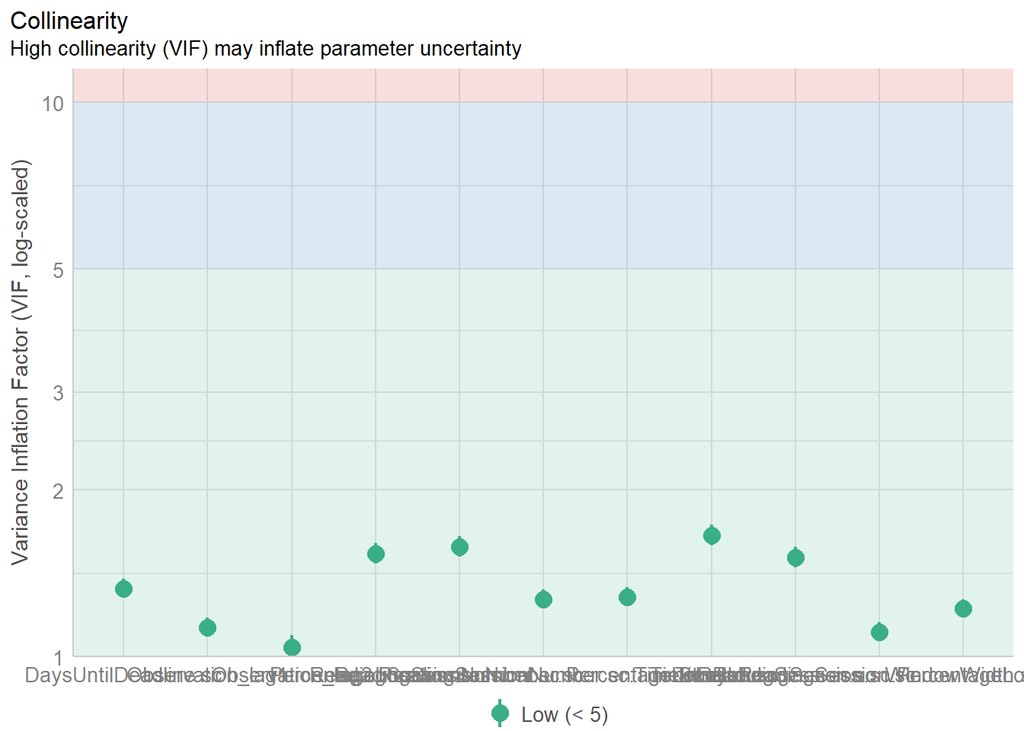

```r
plot(check_collinearity(Linearity_EP_InteractiveModel_adjusted))
```

After removal of the interaction, the model multicollinearity reduces to acceptable levels. Accordingly, we decide to proceed with the adjusted model.

#### 2. Influential Observations

We test influential observations with Cook’s Distance:

```r
cooksd <-
     cooks.distance(Linearity_EP_InteractiveModel_adjusted)
```

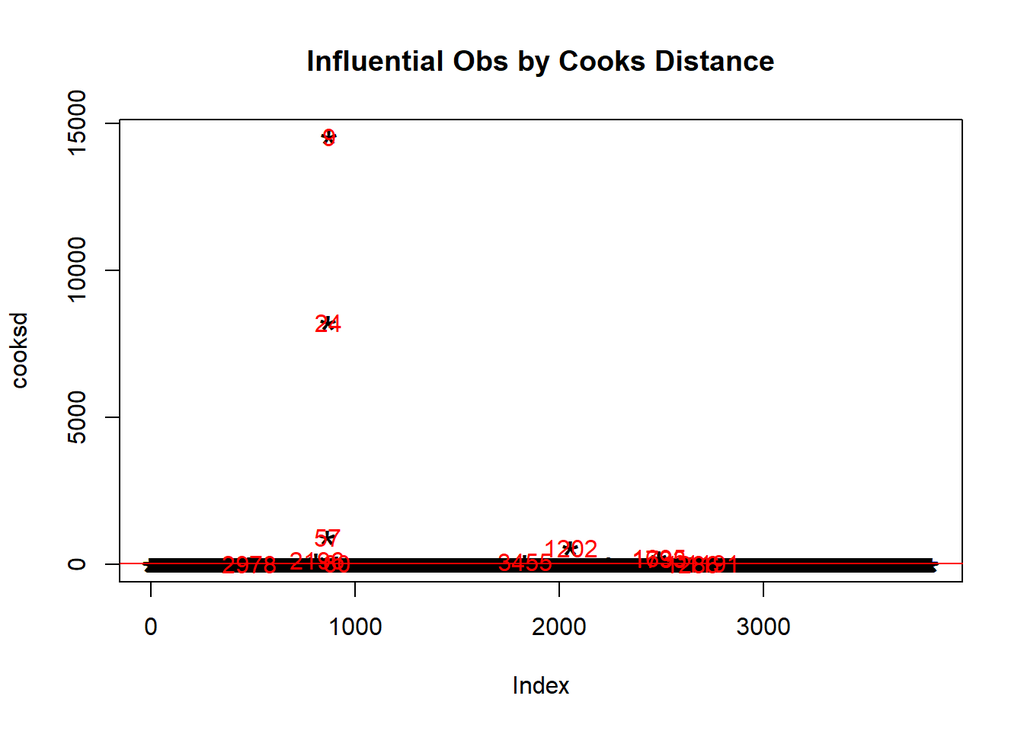

```r
plot(cooksd,
    pch = "*",
     cex = 2,
    main = "Influential Obs by Cooks Distance"
)
abline(h = 4 * mean(cooksd, na.rm = TRUE), col = "red")
text(
    x = 1:length(cooksd) + 1,
    y = cooksd,
     labels = ifelse(cooksd > 4 * mean(cooksd, na.rm = TRUE), names(cooksd), ""),
    col = "red"
)
```

The plot indicates that the dataset may include some highly influential observations. In particular, the plot highlights observations #9 and #24.

We further inspect outliers using the simulated_model_output and DHARMa’s outlier test:

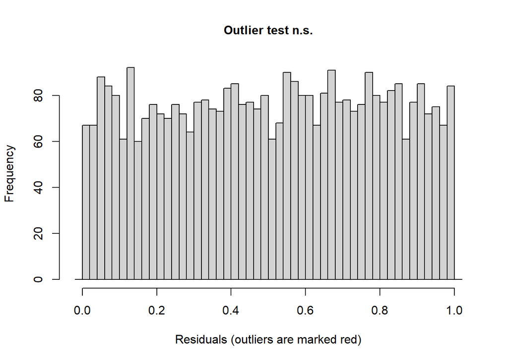

```
##
##  DHARMa outlier test based on exact binomial test with approximate
##  expectations
##
## data:  simulated_model_output
## outliers at both margin(s) = 27, observations = 3819, p-value = 0.6482
## alternative hypothesis: true probability of success is not equal to 0.007968127
## 95 percent confidence interval:
##  0.004664137 0.010269800
## sample estimates:
## frequency of outliers (expected: 0.00796812749003984 )
##                                            0.007069914
```

```r
set.seed(1234) # for reproducibility
simulated_model_output <- DHARMa::simulateResiduals(Linearity_EP_InteractiveModel_adjusted)
testOutliers(simulated_model_output)
```

Although Cook’s Distance indicates that the model has influential observations, the outlier test does not produce the same results. We resolve this contradiction by testing the removal of the most influential observation (#9) from the model to see if its inclusion has an impact on model interpretations.

**Fit the model without observation #9:**

```r
subset_without_observation9 <- linearity_measure_data[c(1:8, 10:nrow(linearity_measure_data)), ]
```

```r
Linearity_EP_InteractiveModel_adjusted_influential <- glmer(
    InteractiveStructure_EP_adjusted,
    data = subset_without_observation9,
    family = binomial(),
    control = glmerControl(optimizer = "bobyqa")
)
```

Inspect if model results are affected:

```r
summary(Linearity_EP_InteractiveModel_adjusted_influential)
```

```
## Generalized linear mixed model fit by maximum likelihood (Laplace
##   Approximation) [glmerMod]
##  Family: binomial  ( logit )
## Formula:
## StartsNonlinearity ~ StoryId + WindowWidth.sc + DaysUntilDeadline.sc +
##     Observation_lag1 + Observation_lag2 + ReadingSessionNumber.sc +
##     TimeInReadingSession.sc + PercentageLocation.sc + ReadingSessionNumber.sc:TimeInReadingSession.sc +
##     ReadingSessionNumber.sc:PercentageLocation.sc + TimeInReadingSession.sc:PercentageLocation.sc +
##     (1 + TimeInReadingSession.sc + Observation_lag1 | UserId)
##    Data: subset_without_observation9
## Control: glmerControl(optimizer = "bobyqa")
##
##      AIC      BIC   logLik deviance df.resid
##   2674.2   2830.4  -1312.1   2624.2     3793
##
## Scaled residuals:
##     Min      1Q  Median      3Q     Max
## -1.1027 -0.3925 -0.2819 -0.1869  7.6351
##
## Random effects:
##  Groups Name                    Variance Std.Dev. Corr
##  UserId (Intercept)             0.3916   0.6258
##         TimeInReadingSession.sc 0.2484   0.4984   -0.26
##         Observation_lag11       1.3863   1.1774    0.50  0.19
## Number of obs: 3818, groups:  UserId, 60
##
## Fixed effects:
##                                                  Estimate Std. Error z value
## (Intercept)                                     -3.171063   0.274148 -11.567
## StoryId1                                         0.321066   0.365854   0.878
## StoryId2                                        -1.005935   0.699608  -1.438
## StoryId3                                         0.612763   0.400102   1.532
## StoryId4                                        -0.118277   0.453184  -0.261
## StoryId5                                        -0.151864   0.365379  -0.416
## StoryId6                                        -0.201689   0.419627  -0.481
## StoryId7                                        -0.272963   0.323573  -0.844
## StoryId8                                        -0.101223   0.382931  -0.264
## WindowWidth.sc                                   0.163405   0.126898   1.288
## DaysUntilDeadline.sc                            -0.099583   0.102013  -0.976
## Observation_lag11                               -1.816659   0.478098  -3.800
```

[output cut: 14 more lines]

```
## StoryId6                                        0.630773
## StoryId7                                        0.398899
## StoryId8                                        0.791520
## WindowWidth.sc                                  0.197854
## DaysUntilDeadline.sc                            0.328974
## Observation_lag11                               0.000145 ***
## Observation_lag21                               0.207146
## ReadingSessionNumber.sc                         0.989858
## TimeInReadingSession.sc                         0.004455 **
## PercentageLocation.sc                           0.816298
## ReadingSessionNumber.sc:TimeInReadingSession.sc 0.432959
## ReadingSessionNumber.sc:PercentageLocation.sc   0.102486
## TimeInReadingSession.sc:PercentageLocation.sc   0.006998 **
## ---
## Signif. codes:  0 '***' 0.001 '**' 0.01 '*' 0.05 '.' 0.1 ' ' 1
```

```
##
## Correlation matrix not shown by default, as p = 19 > 12.
## Use print(x, correlation=TRUE)  or
##     vcov(x)        if you need it
```

```r
summary(Linearity_EP_InteractiveModel_adjusted)
```

```
## Generalized linear mixed model fit by maximum likelihood (Laplace
##   Approximation) [glmerMod]
##  Family: binomial  ( logit )
## Formula:
## StartsNonlinearity ~ StoryId + WindowWidth.sc + DaysUntilDeadline.sc +
##     Observation_lag1 + Observation_lag2 + ReadingSessionNumber.sc +
##     TimeInReadingSession.sc + PercentageLocation.sc + ReadingSessionNumber.sc:TimeInReadingSession.sc +
##     ReadingSessionNumber.sc:PercentageLocation.sc + TimeInReadingSession.sc:PercentageLocation.sc +
##     (1 + TimeInReadingSession.sc + Observation_lag1 | UserId)
##    Data: linearity_measure_data
## Control: glmerControl(optimizer = "bobyqa")
##
##      AIC      BIC   logLik deviance df.resid
##   2674.4   2830.6  -1312.2   2624.4     3794
##
## Scaled residuals:
##     Min      1Q  Median      3Q     Max
## -1.1027 -0.3925 -0.2817 -0.1870  7.6367
##
## Random effects:
##  Groups Name                    Variance Std.Dev. Corr
##  UserId (Intercept)             0.3915   0.6257
##         TimeInReadingSession.sc 0.2493   0.4993   -0.26
##         Observation_lag11       1.3846   1.1767    0.50  0.19
## Number of obs: 3819, groups:  UserId, 60
##
## Fixed effects:
##                                                  Estimate Std. Error z value
## (Intercept)                                     -3.171549   0.274158 -11.568
## StoryId1                                         0.320927   0.366146   0.876
## StoryId2                                        -1.007351   0.700364  -1.438
## StoryId3                                         0.613101   0.400481   1.531
## StoryId4                                        -0.118567   0.453606  -0.261
## StoryId5                                        -0.152001   0.365686  -0.416
## StoryId6                                        -0.205949   0.420067  -0.490
## StoryId7                                        -0.272135   0.323740  -0.841
## StoryId8                                        -0.100510   0.383216  -0.262
## WindowWidth.sc                                   0.163463   0.127006   1.287
## DaysUntilDeadline.sc                            -0.099376   0.102079  -0.974
## Observation_lag11                               -1.815849   0.478029  -3.799
```

[output cut: 14 more lines]

```
## StoryId6                                        0.623938
## StoryId7                                        0.400574
## StoryId8                                        0.793105
## WindowWidth.sc                                  0.198077
## DaysUntilDeadline.sc                            0.330297
## Observation_lag11                               0.000146 ***
## Observation_lag21                               0.207271
## ReadingSessionNumber.sc                         0.992876
## TimeInReadingSession.sc                         0.004502 **
## PercentageLocation.sc                           0.820775
## ReadingSessionNumber.sc:TimeInReadingSession.sc 0.430669
## ReadingSessionNumber.sc:PercentageLocation.sc   0.101539
## TimeInReadingSession.sc:PercentageLocation.sc   0.007095 **
## ---
## Signif. codes:  0 '***' 0.001 '**' 0.01 '*' 0.05 '.' 0.1 ' ' 1
```

```
##
## Correlation matrix not shown by default, as p = 19 > 12.
## Use print(x, correlation=TRUE)  or
##     vcov(x)        if you need it
```

The results are not influenced by removing observation #9, and so we retain it in the sample. Considering that the most influential observation does not appear to affect model results, we believe that the sample does not have any influential observations, in accordance with results from DHARMa::testOutliers().

#### 3. Heteroscedasticity

Test for heteroscedasticity with DHARMa::testQuantiles() using simulated_model_output created earlier

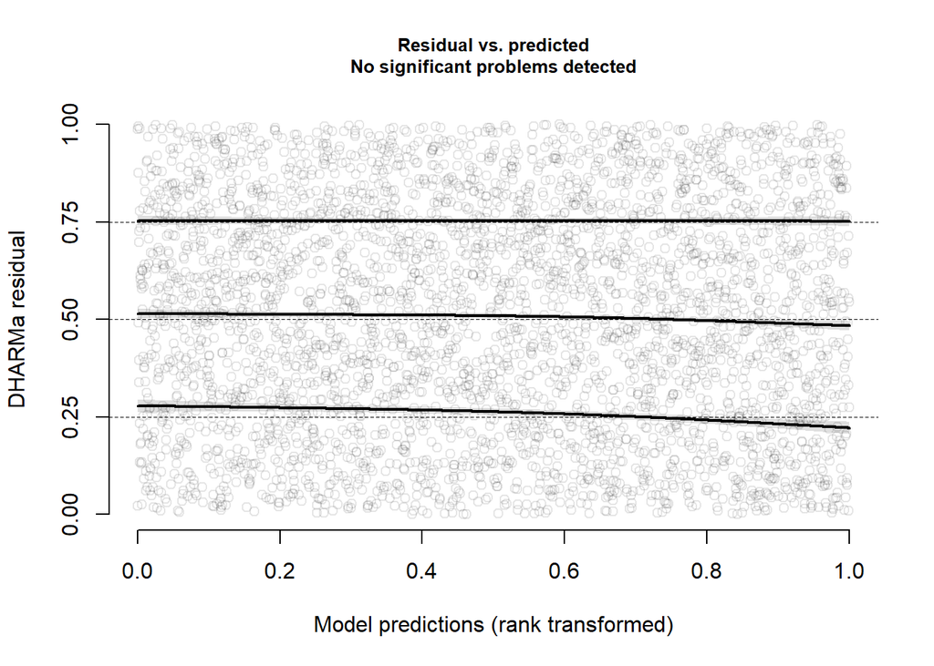

```
##
##  Test for location of quantiles via qgam
##
## data:  simulationOutput
## p-value = 0.1907
## alternative hypothesis: both
```

```r
testQuantiles(simulated_model_output)
```

The p-value is not significant, and the lines lie fairly flat and horizontal in the plot, close to the reference lines. This indicates that the assumption of homoscedasticity is fulfilled.

#### 4. Normality of Random Effects

Random effects should be normally distributed in multilevel models. We test this assumption by inspecting the normality of ‘UserId’. ‘StoryId’ was fit in the model as a fixed effect and so it is not inspected.

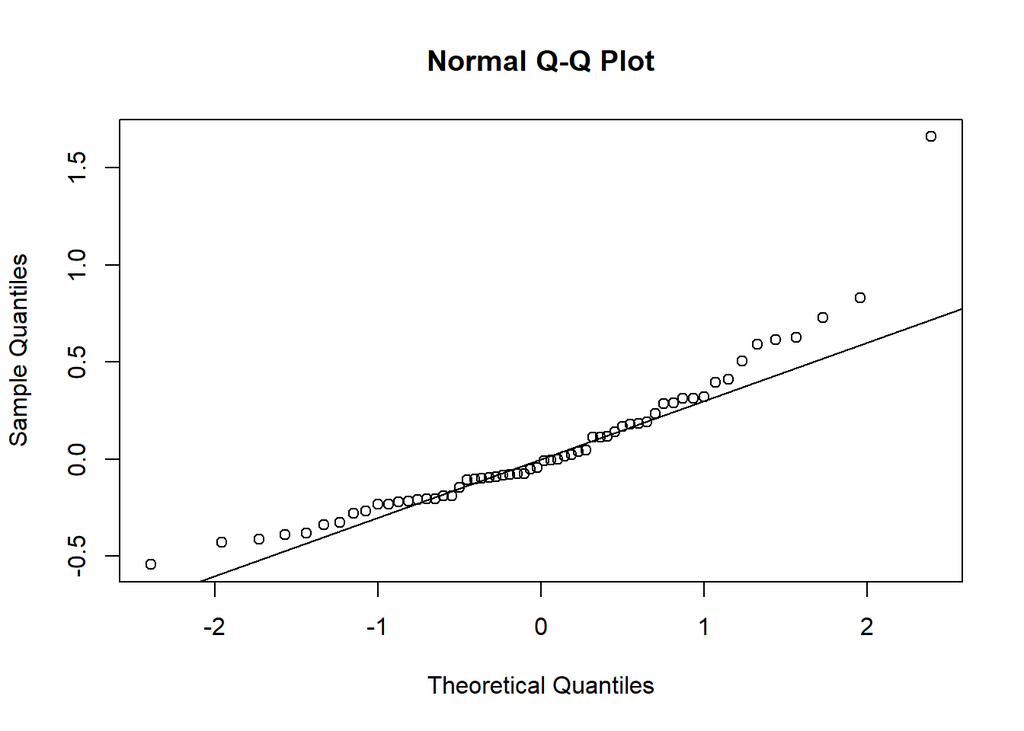

```r
random_intercept_UserId <- ranef(Linearity_EP_InteractiveModel_adjusted)$UserId$`(Intercept)`
qqnorm(random_intercept_UserId)
qqline(random_intercept_UserId)
```

```r
shapiro.test(random_intercept_UserId)
```

```
##
##  Shapiro-Wilk normality test
##
## data:  random_intercept_UserId
## W = 0.88934, p-value = 5.496e-05
```

The qqplot and the Shapiro Wilk test show that the random effect of UserId significantly deviates from a normal distribution. The plot shows that the random effect variances have long tails, and thus higher and lower values are skewed. This nonnormality is likely to bias variance estimations from the random effect of UserId. However, it does not influence interpretation of the fixed effect coefficients [@Shielzeth2020]. Considering that our main aim is to interpret the results from the model rather than estimate UserId variance, we accept this limitation and interpret results with caution.

**Assumptions conclusion**

The model was fit with StoryId as a fixed rather than a random effect to resolve singularity in the model that was due to zero variance accounted for by the StoryId random intercept. The model also showed an elevated VIF score for a two-way interaction between previous events (Event<sub>k-1</sub> and Event<sub>k-2</sub>), indicative of multicollinearity. This was resolved by re-fitting the model without this interaction after inspection of the model showed that the potential multicollinearity may have an impact on the model results.

Finally, inspection of the normality of the random effect of UserId showed that the distribution significantly deviates from normal. It is not possible to exclude or transform the variable without significantly altering the model. Instead, we accept this limitation to the model considering that it does not bias interpretation of fixed effect coefficients, according to a simulation study by @Shielzeth2020.

### Interpret reader characteristics model

We then interpret model effects to interpret the results.

```r
summary(Linearity_EP_InteractiveModel_adjusted)
```

```
## Generalized linear mixed model fit by maximum likelihood (Laplace
##   Approximation) [glmerMod]
##  Family: binomial  ( logit )
## Formula:
## StartsNonlinearity ~ StoryId + WindowWidth.sc + DaysUntilDeadline.sc +
##     Observation_lag1 + Observation_lag2 + ReadingSessionNumber.sc +
##     TimeInReadingSession.sc + PercentageLocation.sc + ReadingSessionNumber.sc:TimeInReadingSession.sc +
##     ReadingSessionNumber.sc:PercentageLocation.sc + TimeInReadingSession.sc:PercentageLocation.sc +
##     (1 + TimeInReadingSession.sc + Observation_lag1 | UserId)
##    Data: linearity_measure_data
## Control: glmerControl(optimizer = "bobyqa")
##
##      AIC      BIC   logLik deviance df.resid
##   2674.4   2830.6  -1312.2   2624.4     3794
##
## Scaled residuals:
##     Min      1Q  Median      3Q     Max
## -1.1027 -0.3925 -0.2817 -0.1870  7.6367
##
## Random effects:
##  Groups Name                    Variance Std.Dev. Corr
##  UserId (Intercept)             0.3915   0.6257
##         TimeInReadingSession.sc 0.2493   0.4993   -0.26
##         Observation_lag11       1.3846   1.1767    0.50  0.19
## Number of obs: 3819, groups:  UserId, 60
##
## Fixed effects:
##                                                  Estimate Std. Error z value
## (Intercept)                                     -3.171549   0.274158 -11.568
## StoryId1                                         0.320927   0.366146   0.876
## StoryId2                                        -1.007351   0.700364  -1.438
## StoryId3                                         0.613101   0.400481   1.531
## StoryId4                                        -0.118567   0.453606  -0.261
## StoryId5                                        -0.152001   0.365686  -0.416
## StoryId6                                        -0.205949   0.420067  -0.490
## StoryId7                                        -0.272135   0.323740  -0.841
## StoryId8                                        -0.100510   0.383216  -0.262
## WindowWidth.sc                                   0.163463   0.127006   1.287
## DaysUntilDeadline.sc                            -0.099376   0.102079  -0.974
## Observation_lag11                               -1.815849   0.478029  -3.799
```

[output cut: 14 more lines]

```
## StoryId6                                        0.623938
## StoryId7                                        0.400574
## StoryId8                                        0.793105
## WindowWidth.sc                                  0.198077
## DaysUntilDeadline.sc                            0.330297
## Observation_lag11                               0.000146 ***
## Observation_lag21                               0.207271
## ReadingSessionNumber.sc                         0.992876
## TimeInReadingSession.sc                         0.004502 **
## PercentageLocation.sc                           0.820775
## ReadingSessionNumber.sc:TimeInReadingSession.sc 0.430669
## ReadingSessionNumber.sc:PercentageLocation.sc   0.101539
## TimeInReadingSession.sc:PercentageLocation.sc   0.007095 **
## ---
## Signif. codes:  0 '***' 0.001 '**' 0.01 '*' 0.05 '.' 0.1 ' ' 1
```

```
##
## Correlation matrix not shown by default, as p = 19 > 12.
## Use print(x, correlation=TRUE)  or
##     vcov(x)        if you need it
```

Linearity of reading is significantly predicted by 1. A main effect of previous event (navigation event k-1, ‘Observation_lag1’) 2. A main effect of time since the beginning of a reading session (‘TimeInReadingSession’) 3. An interaction effect between time in a reading session and location in text

Note that no hypotheses were set for the event properties models and they are used for explorative purposes only.

#### Connection between the outcome variable and previous events

The results of the model indicated that previous event (lag 1) was a significant predictor of nonlinear navigation.

```r
linearity_ep_previousevent <- effect_plot(
    Linearity_EP_InteractiveModel_adjusted,
    pred = "Observation_lag1",
    data =  linearity_measure_data,
    interval = TRUE
) +
    figure_theme_without_legend +
    labs(
        y = addline_format("Odds of initiating,nonlinear navigation (Event k)"),
        x = addline_format("Whether nonlinearity was,initiated in Event k-1")
    ) +
    coord_cartesian(ylim = c(0, 0.3), expand = FALSE) +
    scale_y_continuous(breaks = c(0, 0.1, 0.2, 0.3))
```

```
## Confidence intervals for merMod models is an experimental feature. The
## intervals reflect only the variance of the fixed effects, not the random
## effects.
```

The result indicates that participants were more likely to initiate nonlinear navigation if the previous event did not initiate nonlinearity. In other words, participants were unlikely to move between different types of nonlinear navigation (e.g. from a regression to a forward leap) in consecutive page-views.

In contrast, event<sub>k-2</sub> was not a significant predictor of nonlinearity:

```r
linearity_ep_lag2 <- effect_plot(
    Linearity_EP_InteractiveModel_adjusted,
    pred = "Observation_lag2",
    interval = TRUE,
) +
    figure_theme_without_legend +
    labs(
        y = addline_format("Odds of initiating,nonlinear navigation (Event k)"),
        x = addline_format("Whether nonlinear navigation was,initiated in Event k-2")
    ) +
    coord_cartesian(ylim = c(0, 0.3), expand = FALSE) +
    scale_y_continuous(breaks = c(0, 0.1, 0.2, 0.3))
```

```
## Confidence intervals for merMod models is an experimental feature. The
## intervals reflect only the variance of the fixed effects, not the random
## effects.
```

Therefore, nonlinear navigation could not be predicted on the basis of the event preceeding the previous.

#### Effect of Time in a Reading session and Location in Text

Linearity of reading was significant predicted by the time since the beginning of a reading session.

```r
linearity_ep_time <- effect_plot(
    Linearity_EP_InteractiveModel_adjusted,
    pred = "TimeInReadingSession.sc",
    interval = TRUE
) +
    figure_theme_without_legend +
    labs(
        y = addline_format("Odds of initiating nonlinear navigation"),
        x = addline_format("Time since the beginning of the reading session,(centered and scaled)")
    )
```

```
## Confidence intervals for merMod models is an experimental feature. The
## intervals reflect only the variance of the fixed effects, not the random
## effects.
```

The main effect indicates that the odds of initiating nonlinear navigation were highest at the beginning of a reading session, and the likelihood of nonlinearity decreased further into the reading session. This indicates that participants may have used nonlinearity primarily at the beginning of reading sessions, potentially to assess the story structure or look-back on what they had read previously.

The main effect was qualified by a significant interaction between time in a reading session and location in text.

```r
linearity_ep_timelocation <- interact_plot(
    Linearity_EP_InteractiveModel_adjusted,
    pred = "TimeInReadingSession.sc",
    modx = "PercentageLocation.sc",
    legend.main = addline_format("Location in text,(centered and scaled)"),
    interval = TRUE
) +
    figure_theme_with_top_legend +
    labs(
        y = addline_format("Odds of initiating nonlinear navigation"),
        x = addline_format("Time since the beginning of the reading session,(centered and scaled)")
    )
```

The interaction effect indicates that the odds of nonlinear navigation are the highest if the participant is at the beginning of the story at the beginning of a reading session. The odds of nonlinear navigation decrease towards the end of the reading session.